# Using R to examine some of our tentative data

> _The 'anomalize' package enables a "tidy" workflow for detecting anomalies in data. The main functions are time_decompose(), anomalize(), and time_recompose(). When combined, enabling decompose time series, detect anomalies, and create bands separating the "normal" data from the anomalous data at scale (i.e. for multiple time series). Time series decomposition is used to remove trend and seasonal components via the time*decompose() function and methods include seasonal decomposition of time series by Loess ("stl") and seasonal decomposition by piecewise medians ("twitter").*

> *The anomalize() function implements two methods for anomaly detection of residuals including using an inner quartile range ("iqr"), i.e. the standard IQR approach, and also generalized extreme studentized deviation ("gesd"). These methods are based on those used in the 'forecast' package and the Twitter 'AnomalyDetection' package (fyi, which is built in R as well).*

> *The point here is to get some quick visualization of the dataset using NON MACHINE-LEARNING approaches, just as a ballpark*

```r
install.packages("anomalize")
```

```r
install.packages('tidyverse')
```

```r
install.packages('tibbletime')
```

```r
install.packages('tidyquant')
```

```r
# install libraries
library(anomalize)
library(tidyverse)
library(tibbletime)
library(tidyquant)
```

```r
# fetch data
data <- tq_get('AAPL',
               from = "2019-09-01",
               to = "2020-02-28",
               get = "stock.prices")

# take a peek
head(data)
```

A tibble: 6 × 8

| symbol <chr> | date <date> | open <dbl> | high <dbl> | low <dbl> | close <dbl> | volume <dbl> | adjusted <dbl> |
| --- | --- | --- | --- | --- | --- | --- | --- |
| AAPL | 2019-09-03 | 51.6075 | 51.7450 | 51.0550 | 51.4250 | 80092000 | 50.59437 |
| AAPL | 2019-09-04 | 52.0975 | 52.3700 | 51.8300 | 52.2975 | 76752400 | 51.45277 |
| AAPL | 2019-09-05 | 53.0000 | 53.4925 | 52.8775 | 53.3200 | 95654800 | 52.45875 |
| AAPL | 2019-09-06 | 53.5125 | 53.6050 | 53.1275 | 53.3150 | 77449200 | 52.45384 |
| AAPL | 2019-09-09 | 53.7100 | 54.1100 | 52.7675 | 53.5425 | 109237600 | 52.67767 |
| AAPL | 2019-09-10 | 53.4650 | 54.1950 | 52.9275 | 54.1750 | 127111600 | 53.29994 |

```r
# anomalize
anomalized <- data %>%
  time_decompose(close) %>%
  anomalize(remainder) %>%
  time_recompose()
```

```
Converting from tbl_df to tbl_time.
Auto-index message: index = date

frequency = 5 days

trend = 39 days

Warning message:
"`type_convert()` only converts columns of type 'character'.
- `df` has no columns of type 'character'"
```

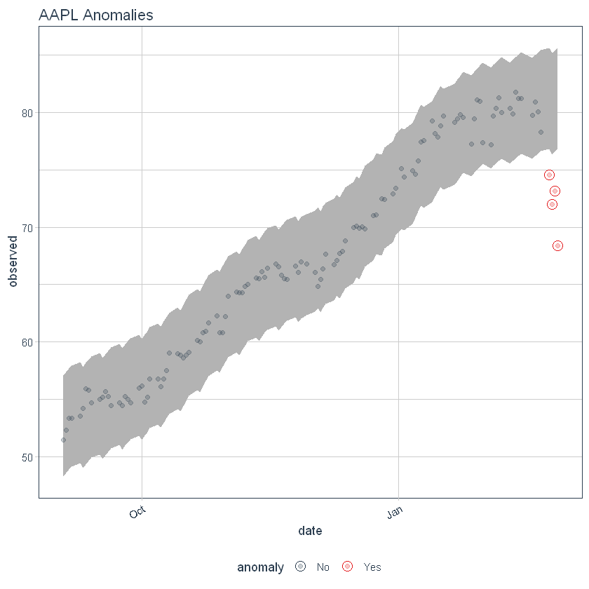

```r
# plot data with anomalies
anomalized %>%
  plot_anomalies(time_recomposed = TRUE, ncol = 3, alpha_dots = 0.25) + labs(title = "AAPL Anomalies")
```

[figure not shown]